# **Factors** affect a loan’s **outcome status**

## by Ibn-Mohey

## Investigation Overview

> determine the **factors** may affect a loan’s **outcome status**

## Dataset Overview

> This data set contains **113,937 loans** with **81 variables** on each loan, including loan **amount**, **borrower rate (or interest rate**), **current loan status**, borrower **income**, and many others.

## Main notes on the Dataset itself

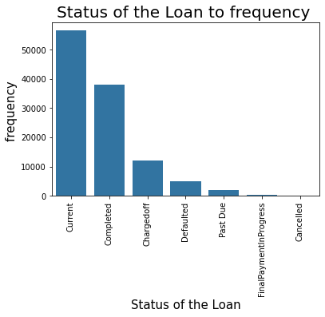

```python
sb.countplot(data = features_df , x = 'LoanStatus', color = bc , order = features_df['LoanStatus'].value_counts().index)
plt.title("Status of the Loan to frequency ", size = 20)
plt.xlabel('Status of the Loan', size = 15)
plt.ylabel('frequency ', size = 15)
plt.xticks(rotation = 90);
plt.show();
```

#### insight

Most of the loans are current or completed. which is good sign

but there is also alot of charged off, defaulted and past due ones

or goal to see what made this happen

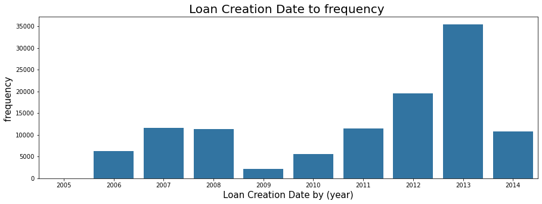

```python
plt.figure(figsize = [15, 5])
sb.countplot(data= features_df, x= 'ListingCreationDate_year', color= bc,)
plt.title("Loan Creation Date to frequency ", size = 20)
plt.xlabel('Loan Creation Date by (year)', size = 15)
plt.ylabel('frequency ', size = 15);
plt.show();
```

#### insight

> it's increasing number over time with big spike at 2013 and decrease at 2014 which i think cuz not all data were collected in 2014

> there is some thing wired from 2007 - 2008 to 2009 and it was **Financial crisis of 2007–2008**

> Financial crisis of 2007–2008 effect can appear here

## Correlation Betweet Variables

```python
overlook_var1 = ['LoanOriginalAmount', 'BorrowerAPR', 'StatedMonthlyIncome','DebtToIncomeRatio','EstimatedEffectiveYield']
overlook_var2 = ['EstimatedEffectiveYield' , 'EstimatedLoss', 'EstimatedReturn', 'LoanOriginalAmount'
                , 'LP_CustomerPayments', 'LP_CustomerPrincipalPayments','LP_InterestandFees','LP_ServiceFees','LP_CollectionFees'
               ,'LP_GrossPrincipalLoss','LP_NetPrincipalLoss','LP_NonPrincipalRecoverypayments']
```

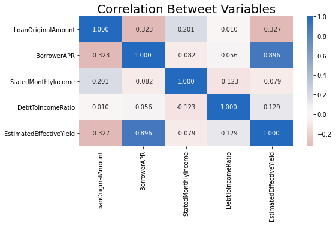

```python
plt.figure(figsize = [8, 4])
sb.heatmap(features_df[overlook_var1].corr(), annot = True, fmt = '.3f',cmap = 'vlag_r', center = 0);
plt.title("Correlation Betweet Variables", size = 20);
```

#### insight

> there is some negative correlation betweet borrower APR and loan original amount with value of **-0.323** and that makes perfect sense

> there is some positive correlation betweet borrower loan original amount and stated monthly income with value of **0.201** another make sense statement as borrowers with more monthly income could loan more money

> some big positive correlation betweet Estimated Effective Yield and BorrowerAPR with vlaue **0.896**

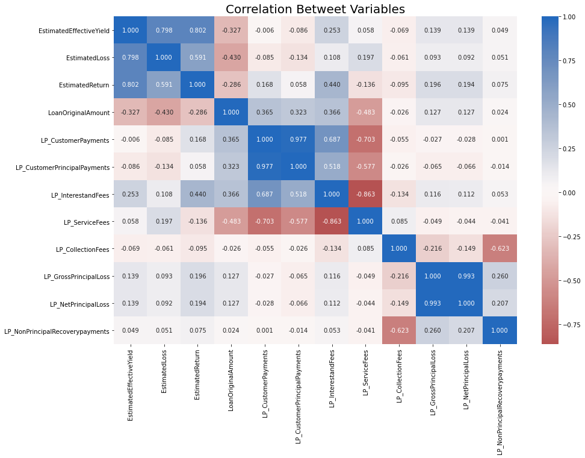

```python
plt.figure(figsize = [15, 10])
sb.heatmap(features_df[overlook_var2].corr(), annot = True, fmt = '.3f', cmap = 'vlag_r', center = 0);
plt.title("Correlation Betweet Variables", size = 20);
```

## LoanStatus and it's factors

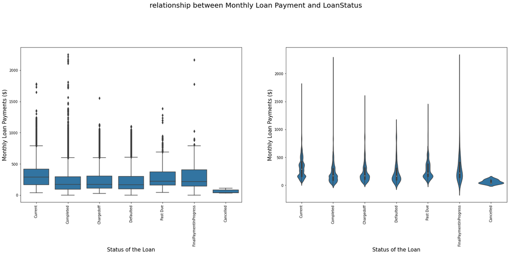

```python
plt.figure(figsize = [25, 18])
plt.subplot(2, 2, 1)
sb.boxplot(data = features_df, x = 'LoanStatus', y = 'MonthlyLoanPayment', color = bc, order = features_df['LoanStatus'].value_counts().index)
plt.xticks(rotation=90, size = 10)
plt.xlabel('Status of the Loan', size = 15)
plt.ylabel('Monthly Loan Payments ($)', size = 15)
plt.subplot(2, 2, 2)
sb.violinplot(data = features_df, x = 'LoanStatus', y = 'MonthlyLoanPayment', color = bc, order = features_df['LoanStatus'].value_counts().index)
plt.xticks(rotation=90, size = 10)
plt.xlabel('Status of the Loan', size = 15)
plt.ylabel('Monthly Loan Payments ($)', size = 15);
plt.suptitle("relationship between Monthly Loan Payment and LoanStatus", size = 20);
```

#### insight

The plots show weird relationship between the **monthly payments** and **the loan Status** loans that are charged-off, loans with past due payments and defaulted loans have almost same **average monthly payments** with others like current and completed

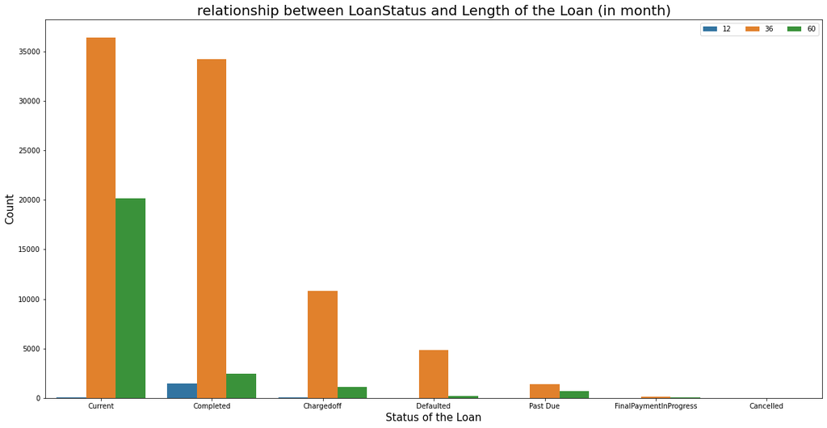

```python
countplotonLoanStatus('Term','Length of the Loan (in month)')
```

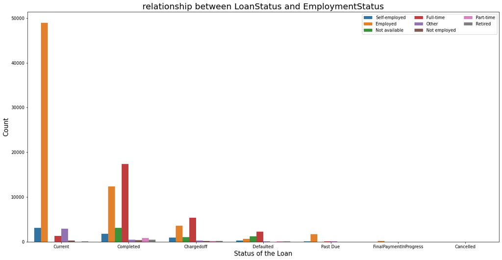

```python
countplotonLoanStatus('EmploymentStatus','EmploymentStatus')
```

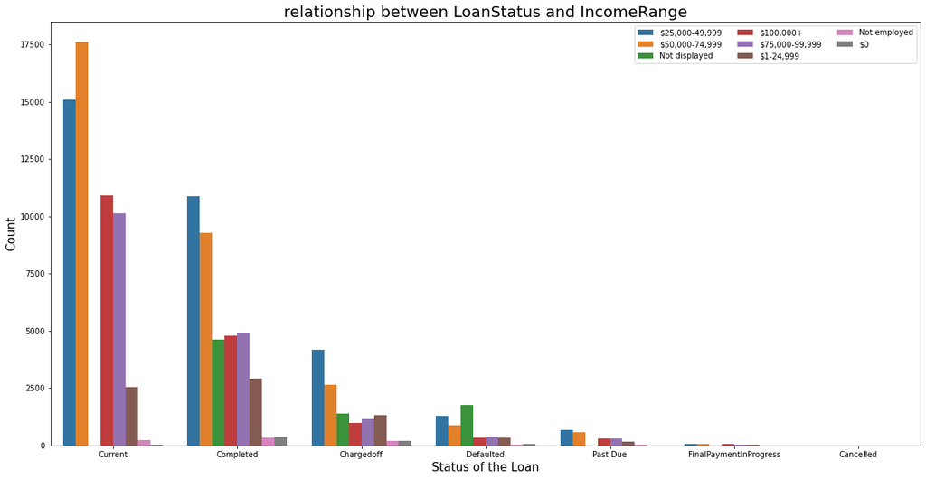

```python
countplotonLoanStatus('IncomeRange','IncomeRange')
```

#### final insight

The **length of the loan** have **NO impact** on the status of the loan.

The **Status of Employment** have **NO impact** on the status of the loan.

## cross interaction between ProsperRating & EmploymentStatus & BorrowerAPR & LoanOriginalAmount with Length of the Loan (in month)

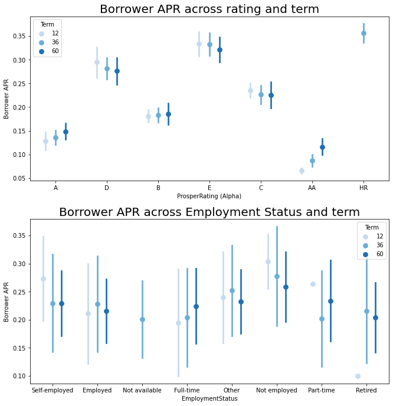

```python
fig = plt.figure(figsize = [10,10])
plt.subplot(2, 1, 1)
ax = sb.pointplot(data = features_df, x = 'ProsperRating (Alpha)', y = 'BorrowerAPR', hue = 'Term',
           palette = 'Blues', linestyles = '', dodge = 0.4, ci='sd')
plt.title('Borrower APR across rating and term', size = 20)
plt.ylabel('Borrower APR')
ax.set_yticklabels([],minor = True);

ax = plt.subplot(2, 1, 2)
plt.tight_layout(pad=3)
ax = sb.pointplot(data = features_df, x = 'EmploymentStatus', y = 'BorrowerAPR', hue = 'Term',
           palette = 'Blues', linestyles = '', dodge = 0.4, ci='sd')
plt.title('Borrower APR across Employment Status and term', size = 20)
plt.ylabel('Borrower APR')
ax.set_yticklabels([],minor = True);
```

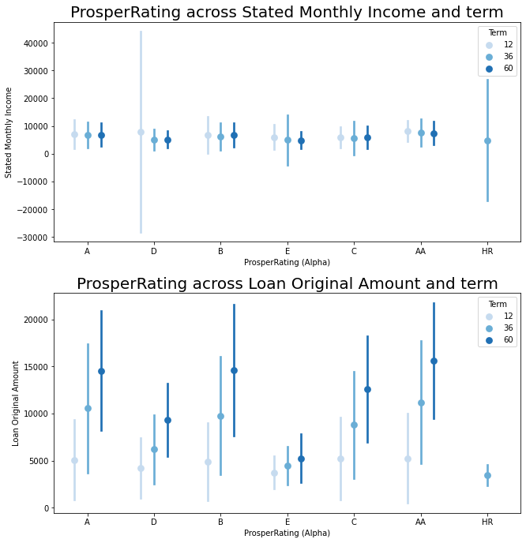

```python
fig = plt.figure(figsize = [10,10])
plt.subplot(2, 1, 1)
ax = sb.pointplot(data = features_df, y = 'StatedMonthlyIncome', x = 'ProsperRating (Alpha)', hue = 'Term',
           palette = 'Blues', linestyles = '', dodge = 0.4, ci='sd')
plt.title('ProsperRating across Stated Monthly Income and term', size = 20)
plt.ylabel('Stated Monthly Income')
ax.set_yticklabels([],minor = True);

ax = plt.subplot(2, 1, 2)
plt.tight_layout(pad=3)
ax = sb.pointplot(data = features_df, y = 'LoanOriginalAmount', x = 'ProsperRating (Alpha)', hue = 'Term',
           palette = 'Blues', linestyles = '', dodge = 0.4, ci='sd')
plt.title('ProsperRating across Loan Original Amount and term', size = 20)
plt.ylabel('Loan Original Amount')
ax.set_yticklabels([],minor = True);
```

### insight

it's looks like as the **borrower APR** **decrease** with the **increase** of borrow **term** for people with **HR-C raings**.

But for people with **B-AA** ratings, the APR **increase** with the **increase of borrow term**

and for stated **monthly income**, **has NO effect** between term and rating, the pattern of term is similar among different ratings.

But for **loan amount**, has an **effect** on **term and rating**. We can see that with **better Prosper rating**, the **loan amount** of all three terms **increases**.